# ds202_lab2

Tyler Kruzan

9/17/2019

# Lab 2

```r
choco <- read.csv("https://raw.githubusercontent.com/lbchu/ds202_labs/master/choco.csv")
head(choco)
```

```
##    Company Specific.Bean.Origin  REF Review.Date Cocoa.Pct
## 1 A. Morin          Agua Grande 1876        2016        63
## 2 A. Morin                Kpime 1676        2015        70
## 3 A. Morin               Panama 1011        2013        70
## 4 A. Morin           Madagascar 1011        2013        70
## 5 A. Morin               Brazil 1011        2013        70
## 6 A. Morin             Equateur 1011        2013        70
##   Company.Location Rating Bean.Type Broad.Bean.Origin
## 1           France   3.75                    Sao Tome
## 2           France   2.75                        Togo
## 3           France   2.75                      Panama
## 4           France   3.00   Criollo        Madagascar
## 5           France   3.25                      Brazil
## 6           France   3.75                     Ecuador
```

## Individual Questions

### 1.How are ratings distributed? Don’t forget to mention outliers, if there are any.

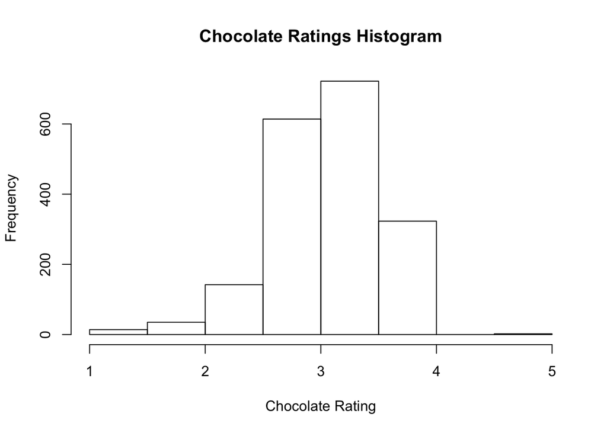

```r
hist(choco$Rating, xlab = "Chocolate Rating", main = "Chocolate Ratings Histogram")
```

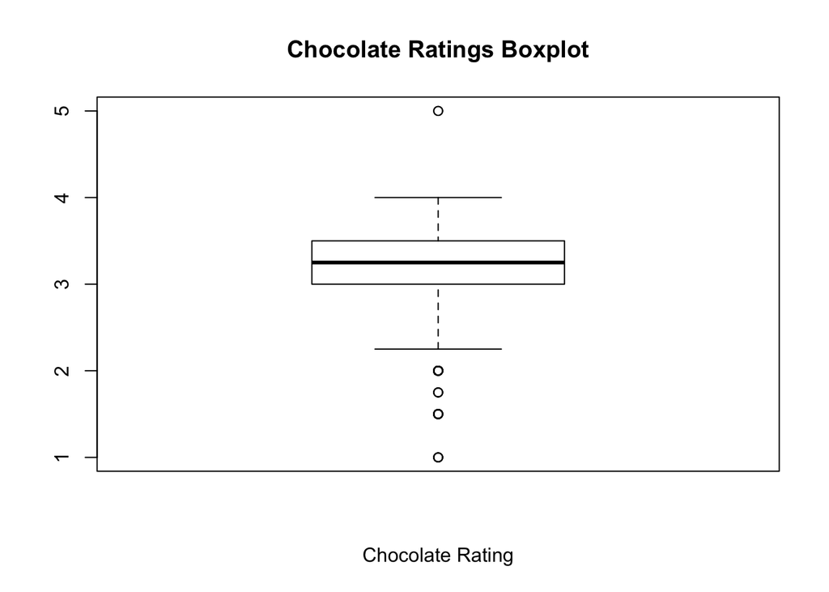

```r
boxplot(choco$Rating, xlab = "Chocolate Rating", main = "Chocolate Ratings Boxplot")
```

### 2.Do ratings depend on the cacao percentage of a chocolate bar?

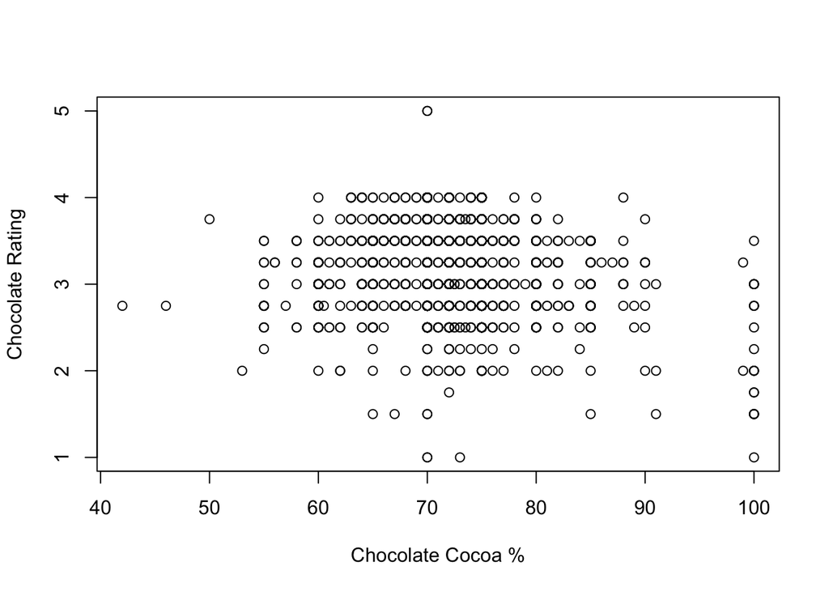

```r
plot(choco$Cocoa.Pct, choco$Rating, xlab = "Chocolate Cocoa %", ylab = "Chocolate Rating")
```

From what can be seen in the scatter plot above, there does not appear to be a relationship between the `Cocoa %` and the `Rating` given to that specific chocolate. Some of the outliers that we can see here are that the highest and lowest rated chcocolate bars are both 70%. There is also a pretty even rating distribution for Cocoa %’s between 55 and 100%.

### 3.What class is the variable representing company locations? How is this different from a ‘character’ variable? (You do not need to produce a graphic for this question.)

```r
class(choco$Company.Location)
```

```
## [1] "factor"
```

From the function I ran above you can see that the class of the `Company.Location` variable is that of a Factor, which is used to represent categorical data and be stored like that of an integer.